## Agenda

Learn to construct and use histograms to examine the underlying distribution of a continuous variable. Specifically

- create a bare bones histogram
- specify the number of bins/intervals
- represent frequency density on the Y axis
- add colors to the bars and the border
- add labels to the bars

## Introduction

A histogram is a plot that can be used to examine the shape and spread of continuous data. It looks very similar to a bar graph and can be used to detect outliers and skewness in data. The histogram graphically shows the following:

- center (location) of the data
- spread (dispersion) of the data
- skewness
- outliers
- presence of multiple modes

## Histograms

To construct a histogram

- the data is split into intervals called bins
- the intervals may or may not be equal sized
- for each bin, the number of data points that fall into it are counted (frequency)
- the Y axis of the histogram represents the frequency and
- the X axis represents the variable

## Histogram

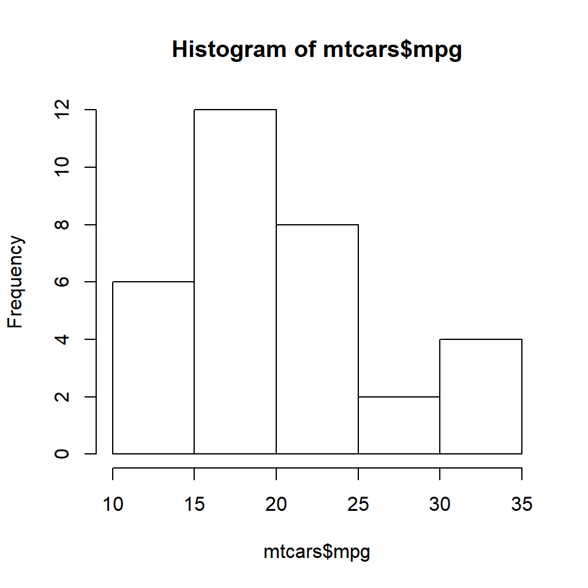

## Histogram

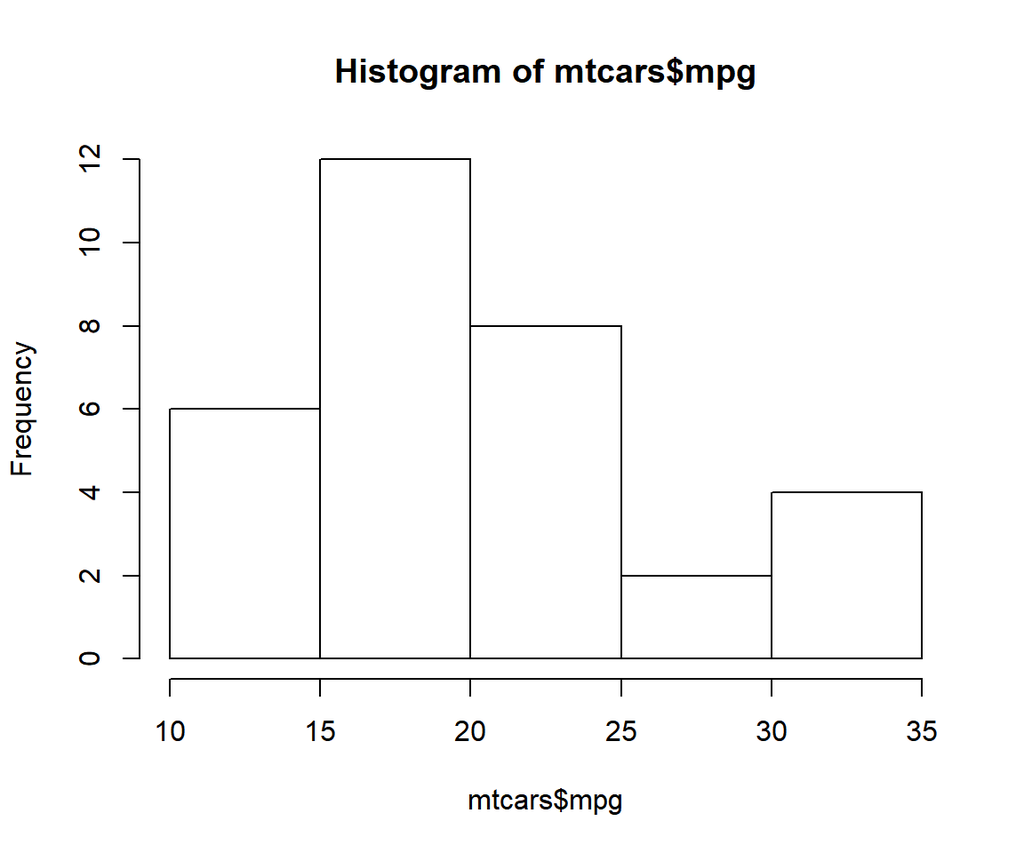

```r
h <- hist(mtcars$mpg)
```

## Histogram

```r
# display number of breaks
h$breaks
```

```
## [1] 10 15 20 25 30 35
```

```r
# frequency of the intervals
h$counts
```

```
## [1]  6 12  8  2  4
```

```r
# frequency density
h$density
```

```
## [1] 0.0375 0.0750 0.0500 0.0125 0.0250
```

```r
# mid points of the intervals
h$mids
```

```
## [1] 12.5 17.5 22.5 27.5 32.5
```

```r
# varible name
h$xname
```

```
## [1] "mtcars$mpg"
```

```r
# whether intervals are of equal size
h$equidist
```

```
## [1] TRUE
```

## Bins

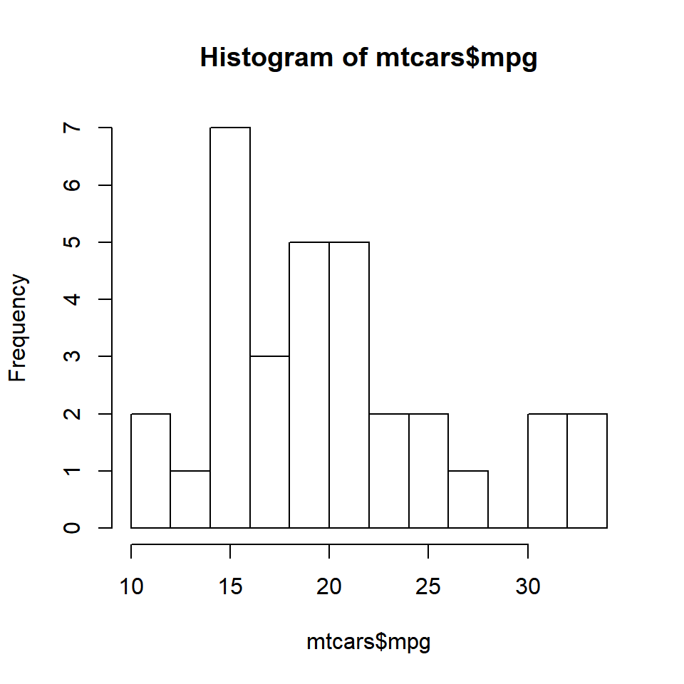

```r
hist(mtcars$mpg, breaks = 10)
```

## Bins

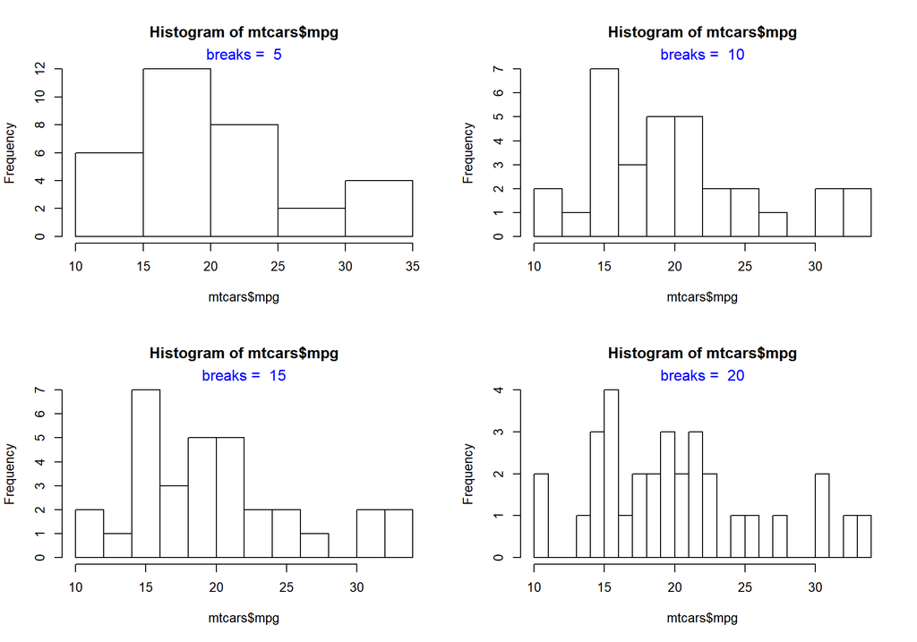

## Intervals

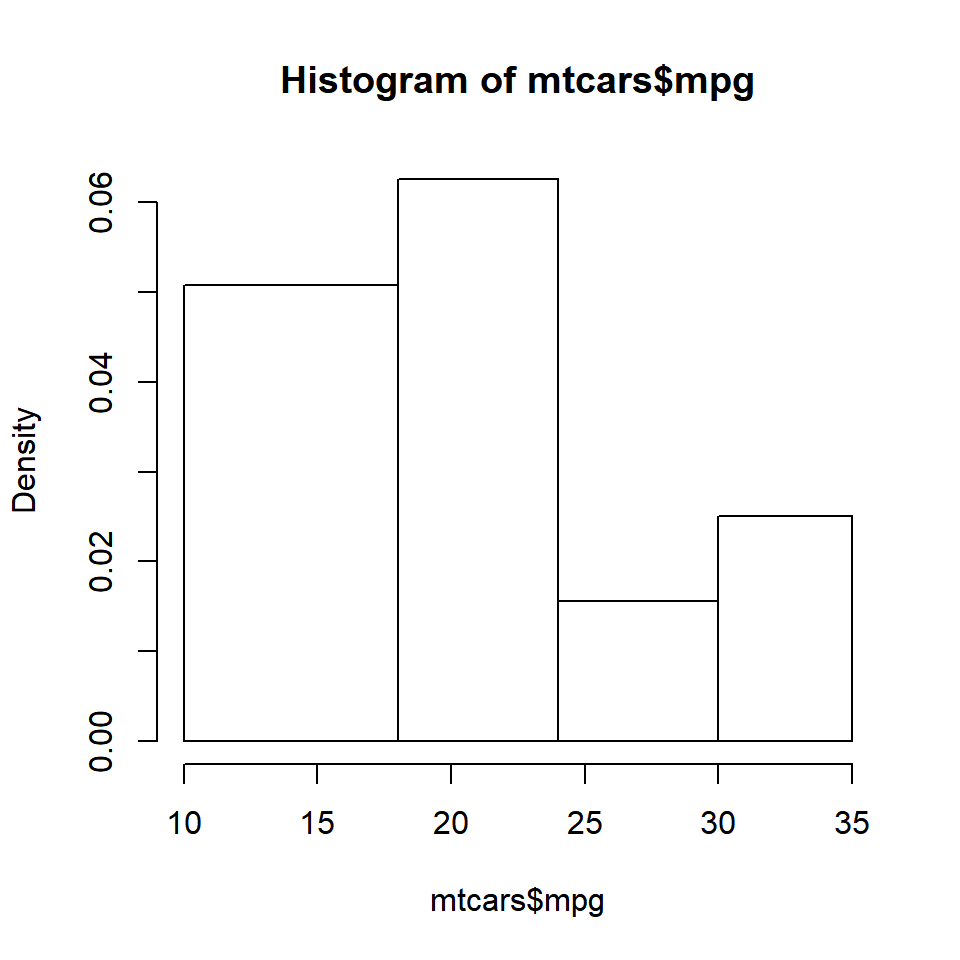

```r
h <- hist(mtcars$mpg, breaks = c(10, 18, 24, 30, 35))
```

## Frequency Density

```r
frequency <- h$counts
class_width <- c(8, 6, 6, 5)
rel_freq <- frequency / length(mtcars$mpg)
freq_density <- rel_freq / class_width
d <- data.frame(frequency = frequency, class_width = class_width,
  relative_frequency = rel_freq, frequency_density = freq_density)
d
```

```
##   frequency class_width relative_frequency frequency_density
## 1        13           8            0.40625        0.05078125
## 2        12           6            0.37500        0.06250000
## 3         3           6            0.09375        0.01562500
## 4         4           5            0.12500        0.02500000
```

## Frequency Density

When multiplied by the class width, the product will always sum upto 1.

```r
sum(d$frequency_density * d$class_width)
```

```
## [1] 1
```

## Intervals

We will learn more about frequency density in a bit. Before we end this section, we need to learn about one more way to specify the intervals of the histogram, algorithms. The `hist()` function allows us to specify the following algorithms:

- Sturges (default)
- Scott
- Freedman-Diaconis (FD)

## Intervals

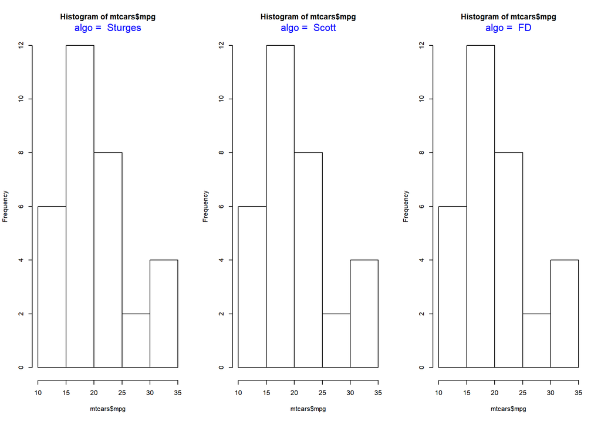

## Frequency Distribution II

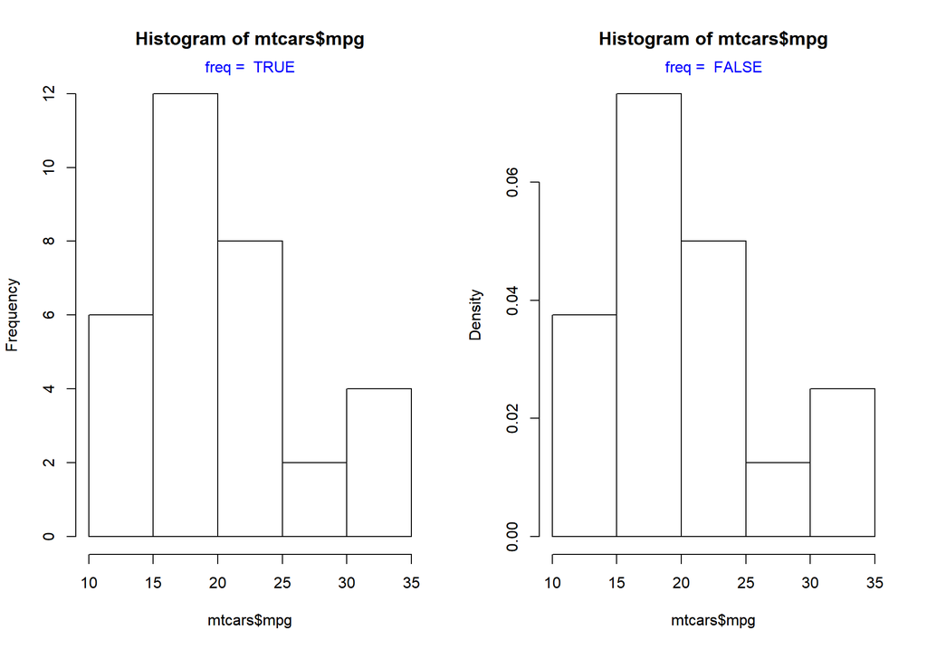

## Probability

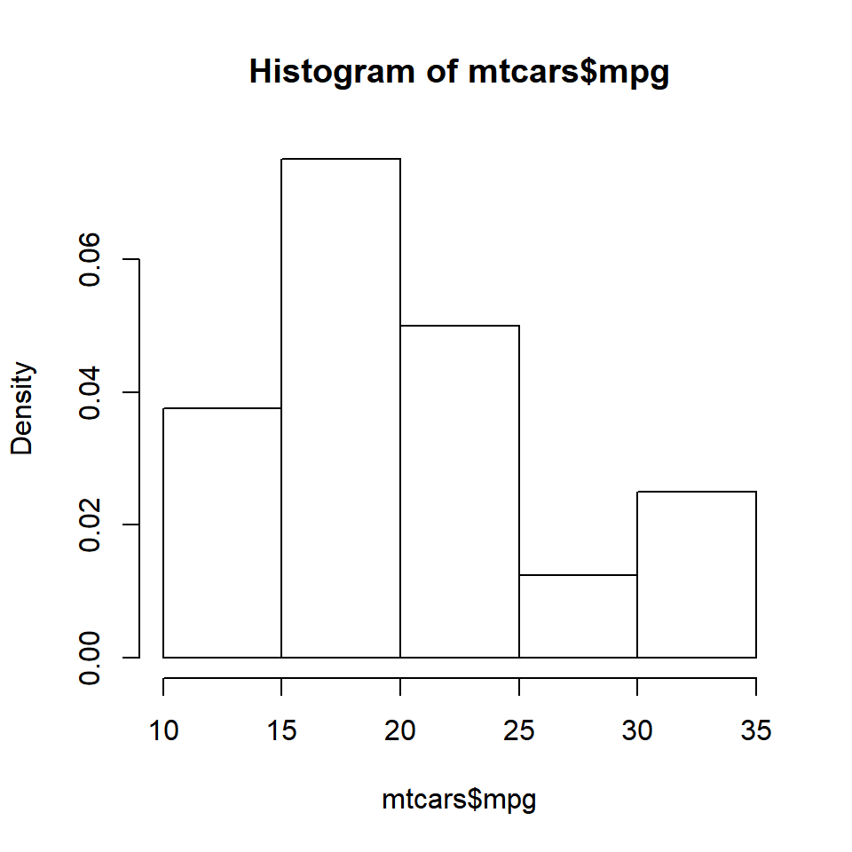

```r
hist(mtcars$mpg, probability = TRUE)
```

## Color

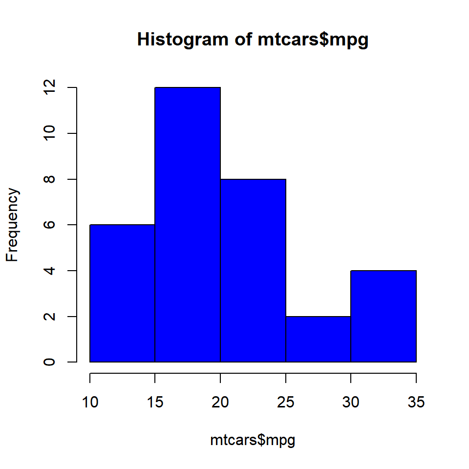

```r
hist(mtcars$mpg, col = 'blue')
```

## Border Color

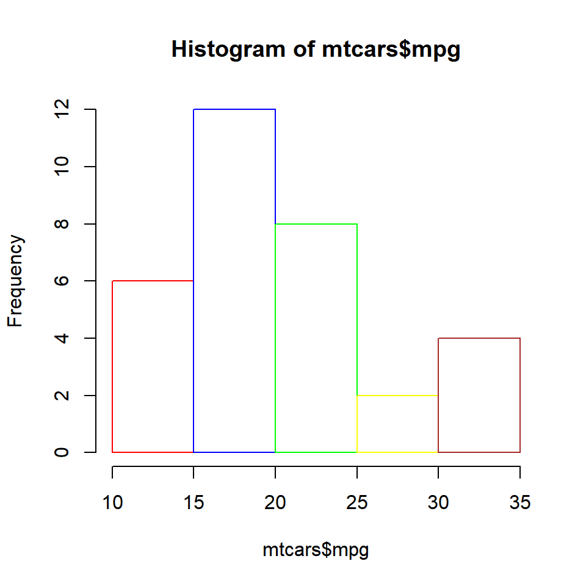

```r
hist(mtcars$mpg, border = c('red', 'blue', 'green', 'yellow', 'brown'))
```

## Labels

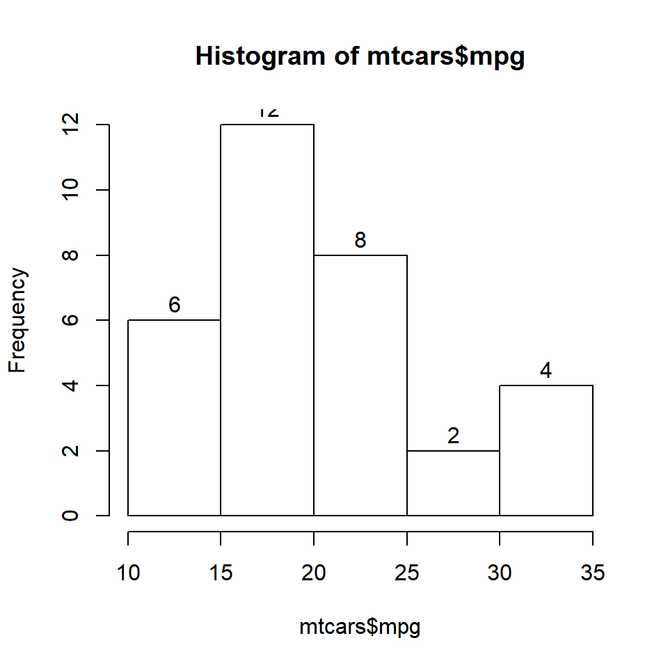

```r
hist(mtcars$mpg, labels = TRUE)
```

## Labels

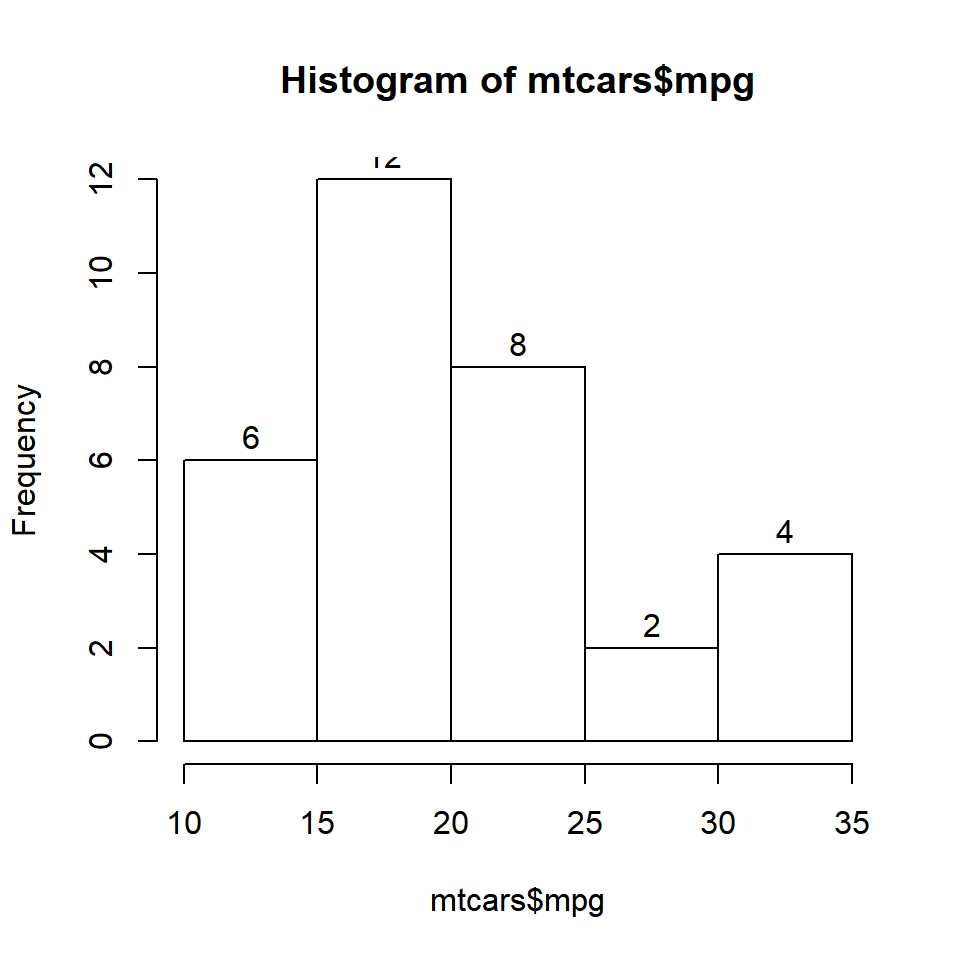

```r
hist(mtcars$mpg, labels = c("6", "12", "8", "2", "4"))
```

## Title & Axis Labels

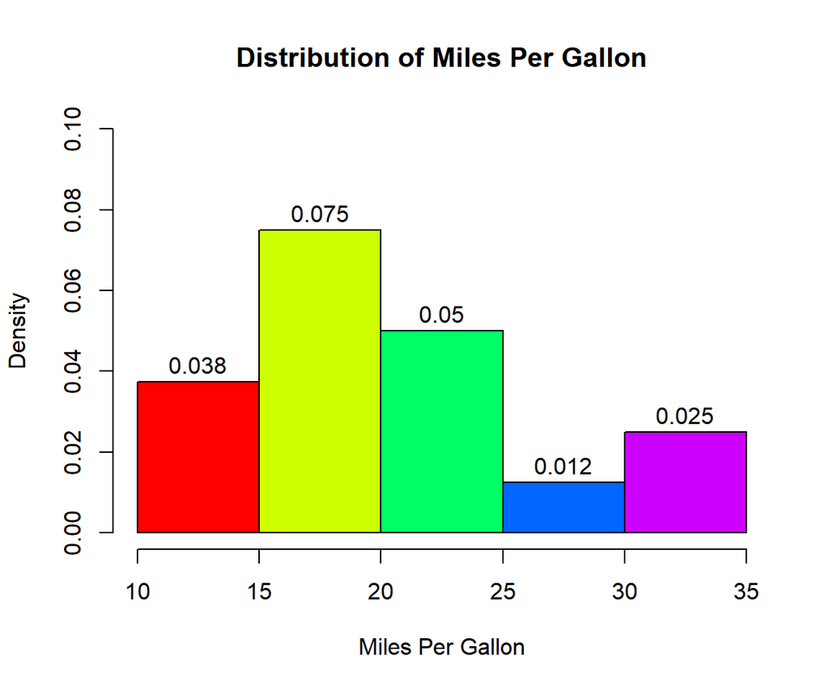

```r
hist(mtcars$mpg, labels = TRUE, prob = TRUE,
     ylim = c(0, 0.1), xlab = 'Miles Per Gallon',
     main = 'Distribution of Miles Per Gallon',
     col = rainbow(5))
```

## Normal Distribution

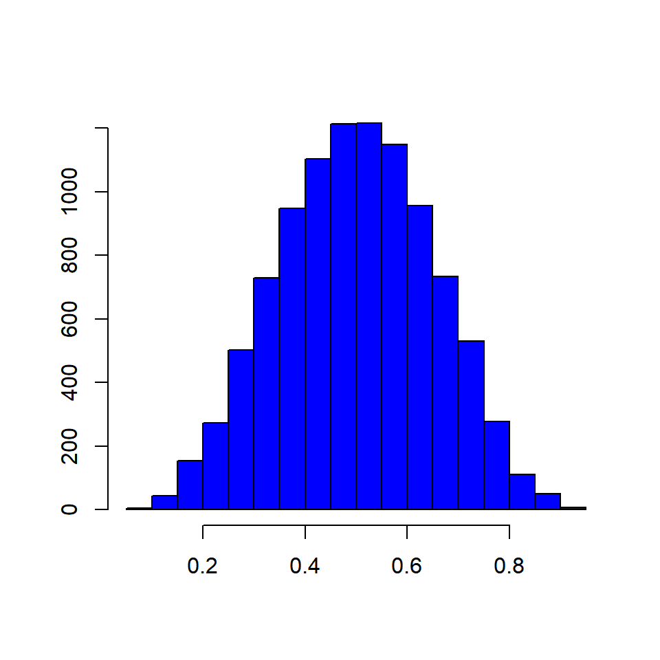

## Skewed Distribution

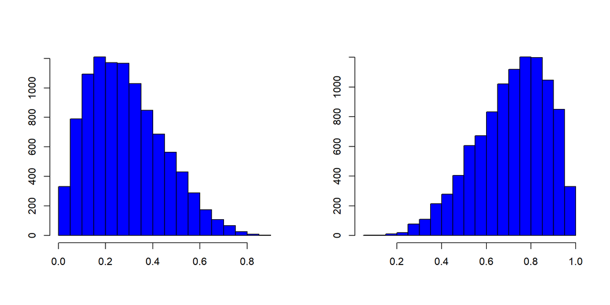

## Case Study

## Data

```r
returns <- read_csv('https://raw.githubusercontent.com/rsquaredacademy/datasets/master/tickers.csv')
```

[output not shown]

## Daily Returns Summary: Apple

```r
summary(returns$AAPL)
```

```
##    Min. 1st Qu.  Median    Mean 3rd Qu.    Max.
## -5.9650 -0.4937  0.1578  0.2573  0.9687  7.2829
```

## Daily Returns: Apple

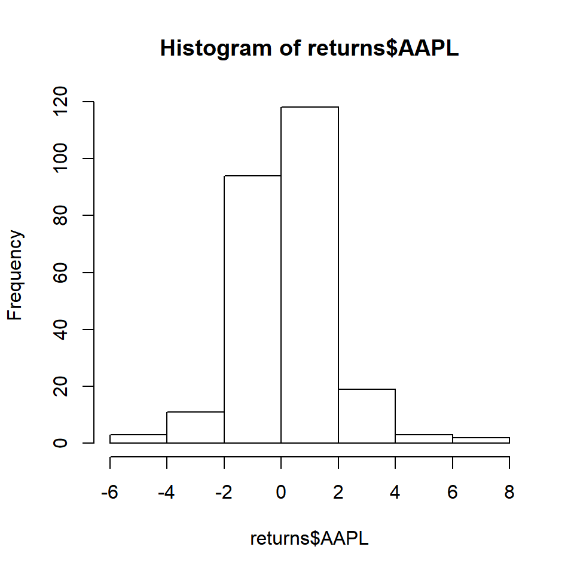

```r
hist(returns$AAPL)
```

## Daily Returns Summary: Google

```r
summary(returns$GOOG)
```

```
##     Min.  1st Qu.   Median     Mean  3rd Qu.     Max.
## -33.5800  -3.1826   1.3950   0.9718   5.8475  31.7100
```

## Daily Returns: Google

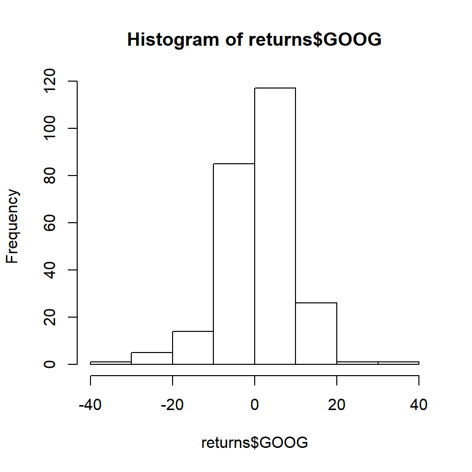

```r
hist(returns$GOOG)
```

## Daily Returns Summary: Facebook

```r
summary(returns$FB)
```

```
##    Min. 1st Qu.  Median    Mean 3rd Qu.    Max.
## -7.6700 -0.5675  0.1300  0.2258  1.1800  4.8300
```

## Daily Returns: Facebook

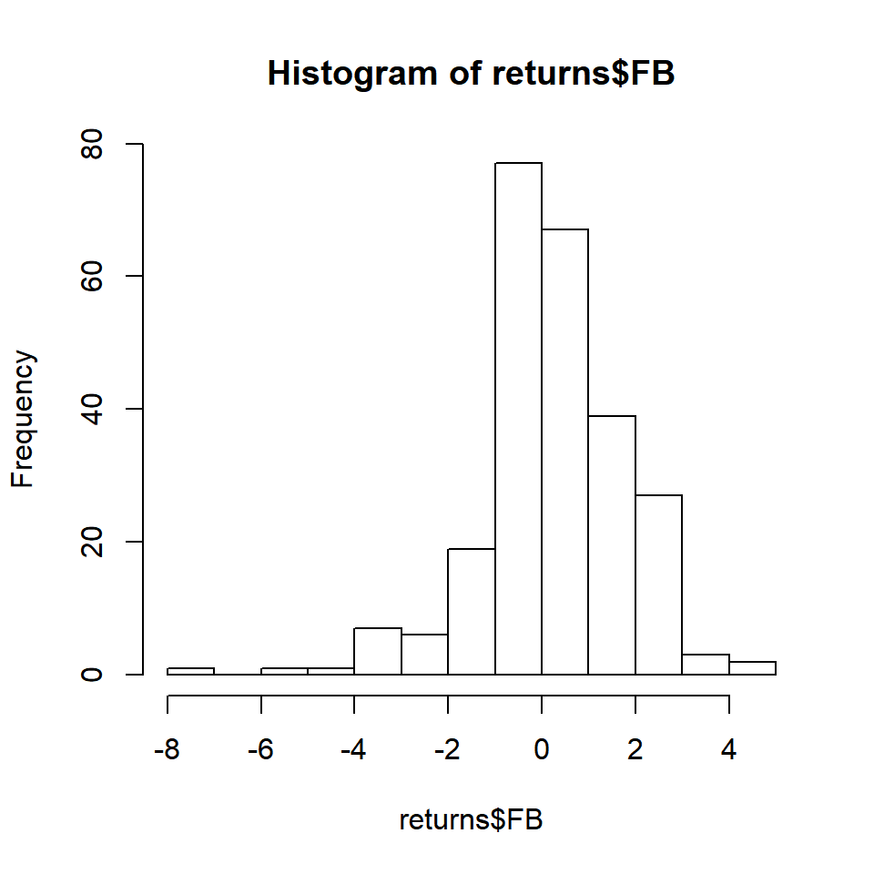

```r
hist(returns$FB)
```

## Daily Returns Summary: Microsoft

```r
summary(returns$MSFT)
```

```
##     Min.  1st Qu.   Median     Mean  3rd Qu.     Max.
## -1.91978 -0.22750  0.04423  0.08851  0.43451  1.65121
```

## Daily Returns: Microsoft

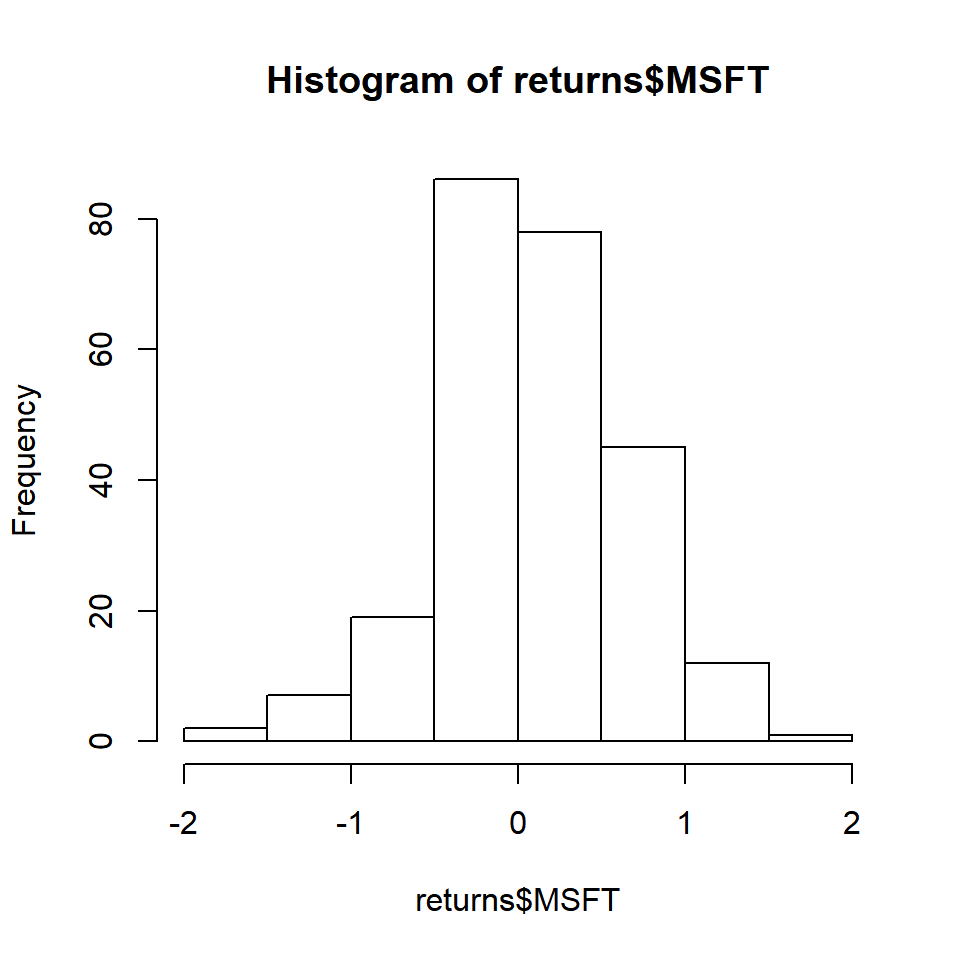

```r
hist(returns$MSFT)
```

## Daily Returns Summary: Amazon

```r
summary(returns$AMZN)
```

```
##    Min. 1st Qu.  Median    Mean 3rd Qu.    Max.
## -32.260  -4.230   0.950   1.126   8.040  24.170
```

## Daily Returns: Amazon

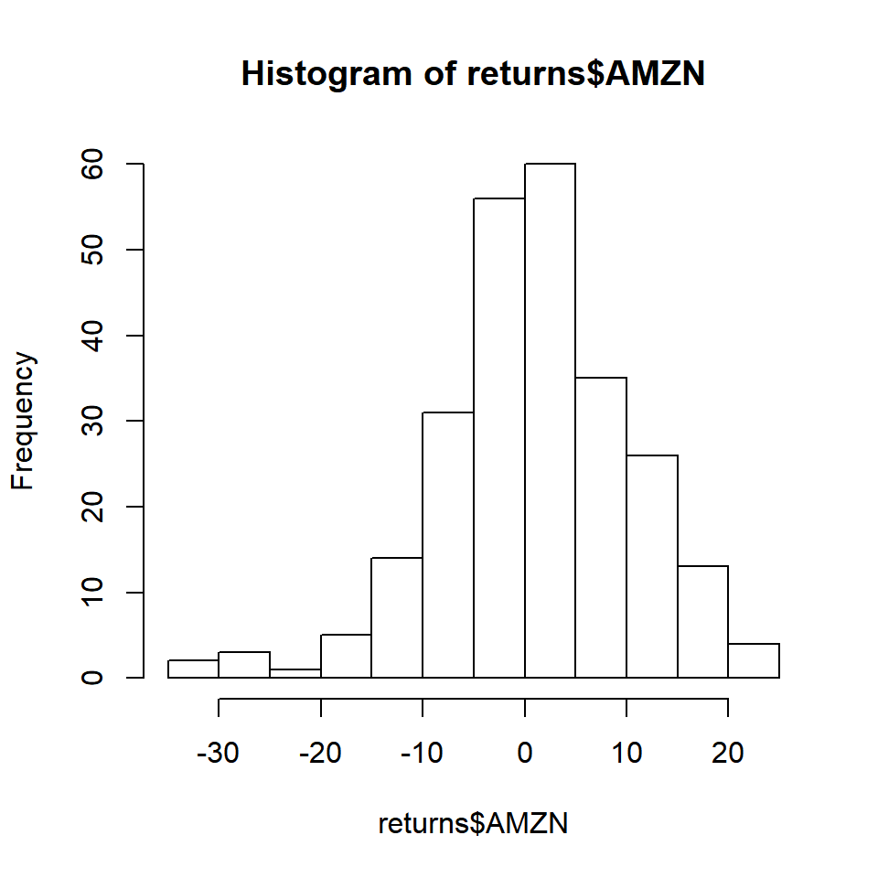

```r
hist(returns$AMZN)
```